# ManyBabies Habituation Project

This project aims to explore infant habituation through looking times using a large harmonised dataset from ManyBabies 1, ManyBabies 3, and ManyBabies 4. Study-relevant materials can be found on the Open Science Framework: https://osf.io/8xm4r

Author

Affiliation

Jasmin Dönicke

University Medical Center Mainz

Published

March 21, 2026

# 1 Shape of habituation curve

Explore which functional forms best capture habituation trajectories.

## 1.1 Prepare Data

```r
# libraries
library(dplyr)
library(ggplot2)
library(lme4)
library(splines)
library(broom.mixed)

# set environment

# read CSV
data <- read.csv("final_merged_manybabies.csv")

# assign factors
data <- data %>%
  mutate(across(where(is.character), as.factor))

# harmonize two age-variables into one
unique(data$age_group_new)
max(data$age_days)

data <- data %>%
  dplyr::mutate(
    age = cut(
      age_days,
      breaks = c(0, 90, 180, 270, 365, 455, 545, 635, 653),  # boundaries in days
      labels = c(
        "< 3 months",
        "3–6 months",
        "6–9 months",
        "9–12 months",
        "12–15 months",
        "15–18 months",
        "18–21 months",
        "> 21 months"
      ),
      right = FALSE
    )
  )

data <- data %>%
  dplyr::mutate(
    age = dplyr::coalesce(age_group_new, age)
  )

data <- data %>%
  dplyr::mutate(
    age = factor(age, levels = c(
      "< 3 months",
      "3–6 months",
      "6–9 months",
      "9–12 months",
      "12–15 months",
      "15–18 months",
      "18–21 months",
      "> 21 months"
    ))
  )

# create variable with only testing trials (Training trials [-2, -1, 0] are excluded because they serve familiarization purposes and are not relevant for the main outcome)
data <- data %>%
  dplyr::mutate(
    testing_trial = ifelse(trial_number > 0, trial_number, NA)
  )

# remove NA for complete-case analysis
data_model <- data %>%
  filter(!is.na(looking_time))
```

## 1.2 Simplify Data

We have roughly 55,000 observations. When testing new code, I can use this smaller sample so things run faster (= use data_sample). Once your code is ready, I will apply it to the full dataset (= use data).

```r
set.seed(123)

data_sample <- data %>%
  dplyr::sample_n(5000)
```

## 1.3 Plot Overall Habituation Curve

The plot shows a steel early habituation (steep drop), which flattens at circa trial No. 4. This looks like a possible non-linear relationship!

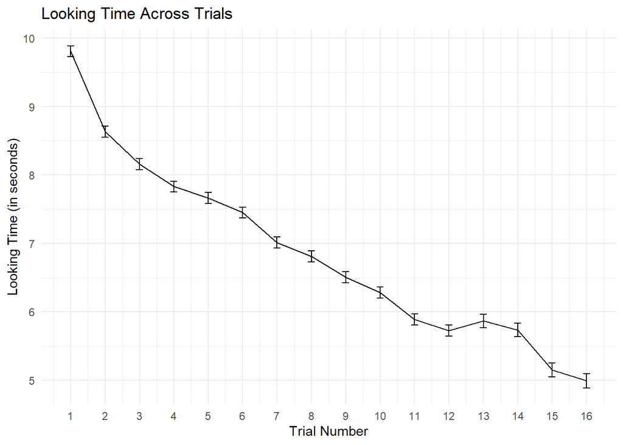

```r
ggplot(data, aes(x = testing_trial, y = looking_time)) +
  stat_summary(fun = mean, geom = "line") +
  stat_summary(fun.data = mean_se, geom = "errorbar", width = 0.2) +
  scale_x_continuous(
    breaks = seq(1, max(data$testing_trial, na.rm = TRUE), by = 1)
  ) +
  labs(
    x = "Trial Number",
    y = "Looking Time (in seconds)",
    title = "Looking Time Across Trials"
  ) +
  theme_minimal()
```

## 1.4 Create Overall Habituation Curve Models

First, I estimate a linear model to assess whether looking time decreases across trials. I then extend this model by including a quadratic term to capture potential curvature in the habituation trajectory. In addition, I fit flexible non-linear models using spline functions to allow for more complex shapes. Importantly, I always use mixed-models with infant-level random intercepts, to account for repeated measurements within infants.

```r
model_linear_mixed <- lmer(looking_time ~ testing_trial + (1 | unique_subject_identifier), data = data_model)

model_quadratic_mixed <- lmer(
  looking_time ~ testing_trial + I(testing_trial^2) + (1 | unique_subject_identifier),
  data = data_model
)

model_spline_mixed <- lmer(
  looking_time ~ ns(testing_trial, df = 3) + (1 | unique_subject_identifier),
  data = data_model
)
```

### 1.4.1 Linear Model

```r
summary(model_linear_mixed)
```

```
Linear mixed model fit by REML ['lmerMod']
Formula: looking_time ~ testing_trial + (1 | unique_subject_identifier)
   Data: data_model

REML criterion at convergence: 270097.2

Scaled residuals:
    Min      1Q  Median      3Q     Max
-3.9077 -0.6142 -0.0862  0.4642  4.8586

Random effects:
 Groups                    Name        Variance Std.Dev.
 unique_subject_identifier (Intercept) 10.49    3.239
 Residual                              11.98    3.462
Number of obs: 48989, groups:  unique_subject_identifier, 3856

Fixed effects:
               Estimate Std. Error t value
(Intercept)    9.159646   0.060976  150.22
testing_trial -0.273134   0.003752  -72.79

Correlation of Fixed Effects:
            (Intr)
testing_trl -0.436
```

```r
broom.mixed::tidy(model_linear_mixed, conf.int = TRUE)
```

```
# A tibble: 4 × 8
  effect   group           term  estimate std.error statistic conf.low conf.high
  <chr>    <chr>           <chr>    <dbl>     <dbl>     <dbl>    <dbl>     <dbl>
1 fixed    <NA>            (Int…    9.16    0.0610      150.     9.04      9.28
2 fixed    <NA>            test…   -0.273   0.00375     -72.8   -0.280    -0.266
3 ran_pars unique_subject… sd__…    3.24   NA            NA     NA        NA
4 ran_pars Residual        sd__…    3.46   NA            NA     NA        NA
```

### 1.4.2 Quadratic Model

- There is a significant decrease in looking time across trials (Slope = -0.49 [95% CI -0.516, -0.459], t = -33.69) and a significant positive quadratic effect (b = 0.013, t = 15.33).
- This indicates that looking-time decreased rapidly at early trials and then leveled off over time, consistent with a typical habituation trajectory.

```r
summary(model_quadratic_mixed)
```

```
Linear mixed model fit by REML ['lmerMod']
Formula:
looking_time ~ testing_trial + I(testing_trial^2) + (1 | unique_subject_identifier)
   Data: data_model

REML criterion at convergence: 269875.2

Scaled residuals:
    Min      1Q  Median      3Q     Max
-3.8508 -0.6106 -0.0901  0.4738  4.7339

Random effects:
 Groups                    Name        Variance Std.Dev.
 unique_subject_identifier (Intercept) 10.51    3.241
 Residual                              11.92    3.453
Number of obs: 48989, groups:  unique_subject_identifier, 3856

Fixed effects:
                     Estimate Std. Error t value
(Intercept)         9.7549907  0.0722978  134.93
testing_trial      -0.4872270  0.0144626  -33.69
I(testing_trial^2)  0.0133719  0.0008725   15.33

Correlation of Fixed Effects:
            (Intr) tstng_
testing_trl -0.614
I(tstng_^2)  0.537 -0.966
```

```r
broom.mixed::tidy(model_quadratic_mixed, conf.int = TRUE)
```

```
# A tibble: 5 × 8
  effect   group           term  estimate std.error statistic conf.low conf.high
  <chr>    <chr>           <chr>    <dbl>     <dbl>     <dbl>    <dbl>     <dbl>
1 fixed    <NA>            (Int…   9.75    0.0723       135.    9.61      9.90
2 fixed    <NA>            test…  -0.487   0.0145       -33.7  -0.516    -0.459
3 fixed    <NA>            I(te…   0.0134  0.000873      15.3   0.0117    0.0151
4 ran_pars unique_subject… sd__…   3.24   NA             NA    NA        NA
5 ran_pars Residual        sd__…   3.45   NA             NA    NA        NA
```

### 1.4.3 Spline Model

- There is a significant nonlinear decrease in looking time across trials.
- Splines cannot be interpreted as easily.
- The spline model provided the best fit to the data compared to linear and quadratic models, indicating that habituation follows a nonlinear trajectory characterized by a rapid initial decrease and subsequent leveling off. This pattern is consistent with typical habituation processes.

```r
# A mixed-effects model using natural splines revealed.
summary(model_spline_mixed)
```

```
Linear mixed model fit by REML ['lmerMod']
Formula:
looking_time ~ ns(testing_trial, df = 3) + (1 | unique_subject_identifier)
   Data: data_model

REML criterion at convergence: 269816

Scaled residuals:
    Min      1Q  Median      3Q     Max
-3.8651 -0.6105 -0.0907  0.4706  4.7878

Random effects:
 Groups                    Name        Variance Std.Dev.
 unique_subject_identifier (Intercept) 10.52    3.244
 Residual                              11.91    3.451
Number of obs: 48989, groups:  unique_subject_identifier, 3856

Fixed effects:
                           Estimate Std. Error t value
(Intercept)                 9.42932    0.06825  138.15
ns(testing_trial, df = 3)1 -2.34500    0.06781  -34.58
ns(testing_trial, df = 3)2 -5.85202    0.11268  -51.94
ns(testing_trial, df = 3)3 -3.03741    0.05986  -50.74

Correlation of Fixed Effects:
            (Intr) n(_,d=3)1 n(_,d=3)2
ns(t_,d=3)1 -0.093
ns(t_,d=3)2 -0.571 -0.082
ns(t_,d=3)3 -0.128 -0.106     0.367
```

```r
broom.mixed::tidy(model_spline_mixed, conf.int = TRUE)
```

```
# A tibble: 6 × 8
  effect   group           term  estimate std.error statistic conf.low conf.high
  <chr>    <chr>           <chr>    <dbl>     <dbl>     <dbl>    <dbl>     <dbl>
1 fixed    <NA>            (Int…     9.43    0.0683     138.      9.30      9.56
2 fixed    <NA>            ns(t…    -2.34    0.0678     -34.6    -2.48     -2.21
3 fixed    <NA>            ns(t…    -5.85    0.113      -51.9    -6.07     -5.63
4 fixed    <NA>            ns(t…    -3.04    0.0599     -50.7    -3.15     -2.92
5 ran_pars unique_subject… sd__…     3.24   NA           NA      NA        NA
6 ran_pars Residual        sd__…     3.45   NA           NA      NA        NA
```

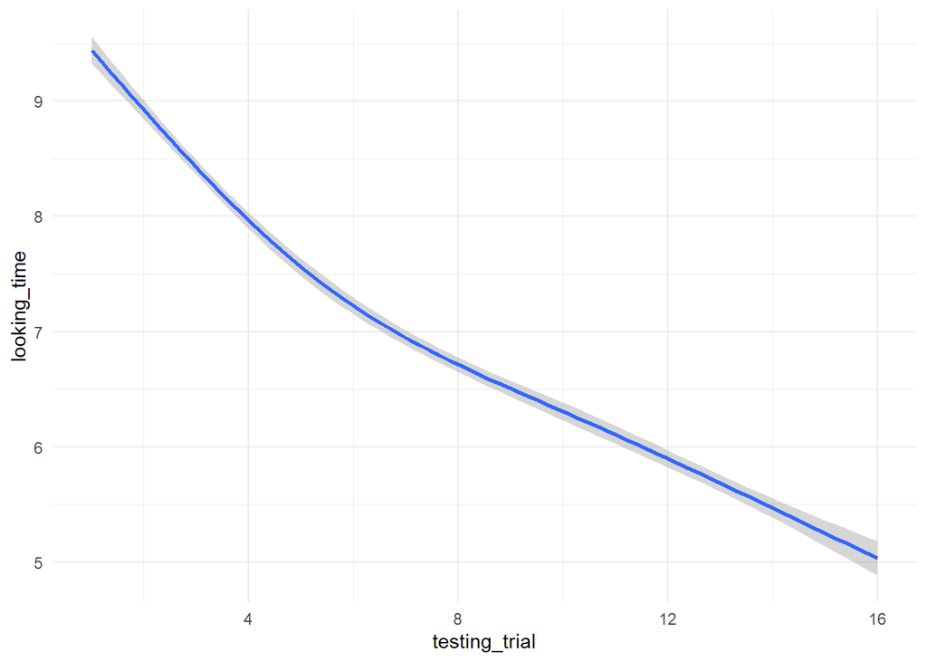

```r
# Plot Spline Model
ggplot(data_model, aes(x = testing_trial, y = looking_time)) +
  geom_smooth(method = "lm",
              formula = y ~ splines::ns(x, df = 3),
              se = TRUE) +
  theme_minimal()
```

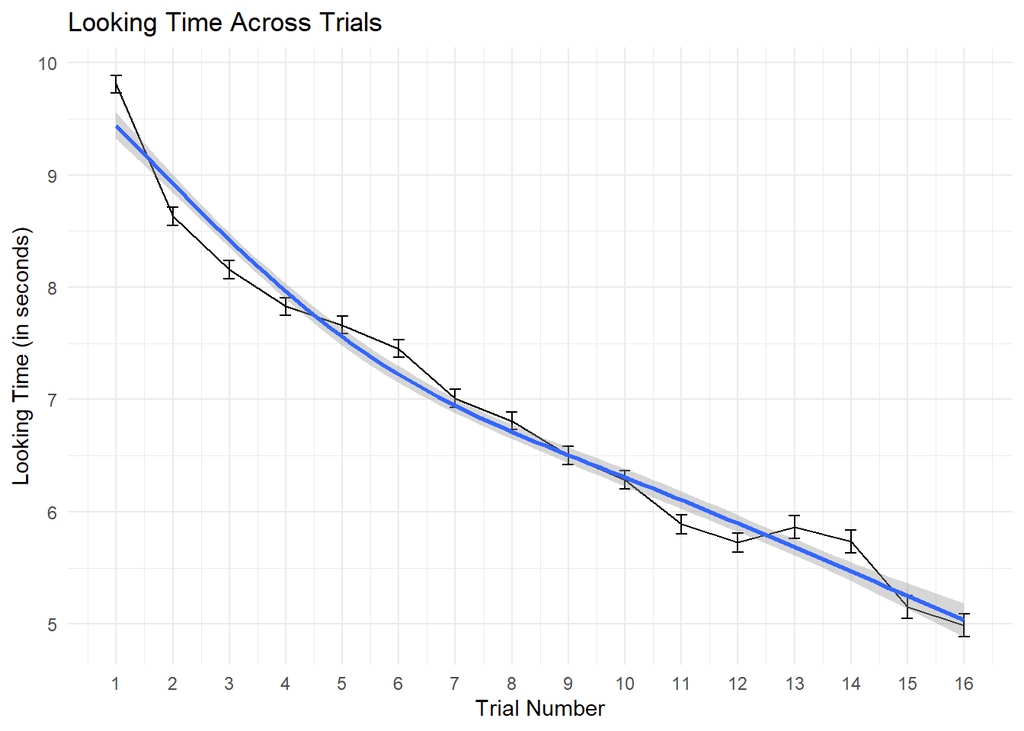

```r
# Plot Spline Model on top of observed data
ggplot(data, aes(x = testing_trial, y = looking_time)) +
  stat_summary(fun = mean, geom = "line") +
  stat_summary(fun.data = mean_se, geom = "errorbar", width = 0.2) +
  scale_x_continuous(
    breaks = seq(1, max(data$testing_trial, na.rm = TRUE), by = 1)
  ) +
  labs(
    x = "Trial Number",
    y = "Looking Time (in seconds)",
    title = "Looking Time Across Trials"
  ) +
  geom_smooth(method = "lm",
              formula = y ~ splines::ns(x, df = 3),
              se = TRUE) +
  theme_minimal()
```

```r
# Here, I am showing the average observed habituation pattern and overlaying a smooth model-based curve to see how well a nonlinear trajectory captures it.
```

## 1.5 Compare Overall Habituation Curve Model Fit

Here, I compare models based on goodness-of-fit criteria (e.g. AIC).

```r
AIC(model_linear_mixed, model_quadratic_mixed, model_spline_mixed)
```

```
                      df      AIC
model_linear_mixed     4 270105.2
model_quadratic_mixed  5 269885.2
model_spline_mixed     6 269828.0
```

```r
BIC(model_linear_mixed, model_quadratic_mixed, model_spline_mixed)
```

```
                      df      BIC
model_linear_mixed     4 270140.4
model_quadratic_mixed  5 269929.2
model_spline_mixed     6 269880.8
```

Here, I compare models by visual inspection of fitted trajectories. This allows me to evaluate whether habituation follows a linear decline, shows rapid early decreases with later stabilization, or exhibits more complex patterns.

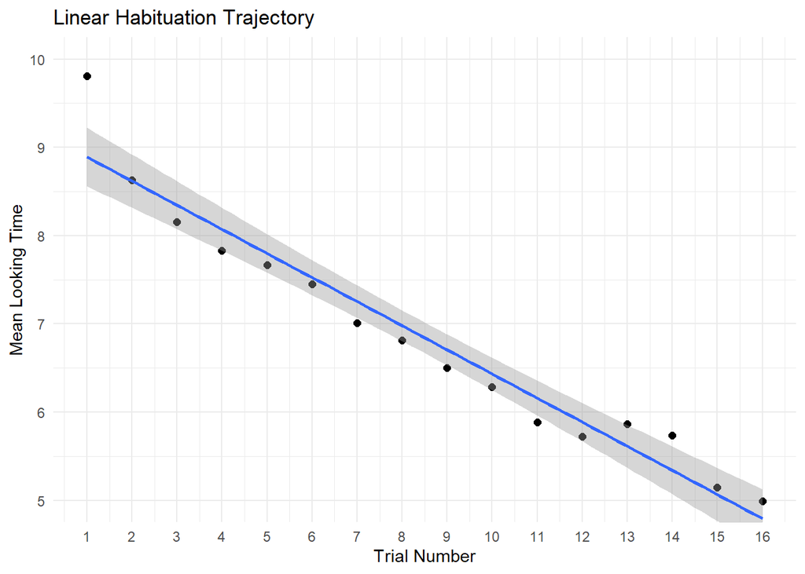

```r
data_summary <- data_model %>%
  group_by(testing_trial) %>%
  summarise(
    mean_lt = mean(looking_time, na.rm = TRUE),
    sd_lt = sd(looking_time, na.rm = TRUE),
    n = sum(!is.na(looking_time)),
    se_lt = sd_lt / sqrt(n),
    ci_low = mean_lt - 1.96 * se_lt,
    ci_high = mean_lt + 1.96 * se_lt,
    .groups = "drop"
  )

# Linear Model
ggplot(data_summary, aes(x = testing_trial, y = mean_lt)) +
  geom_point(size = 2) +
  geom_smooth(method = "lm", formula = y ~ x, se = TRUE, level = 0.95) +
  labs(
    x = "Trial Number",
    y = "Mean Looking Time",
    title = "Linear Habituation Trajectory"
  ) +
  coord_cartesian(ylim = c(5, 10)) +
   scale_x_continuous(
    breaks = seq(1, max(data$testing_trial, na.rm = TRUE), by = 1)
  ) +
  theme_minimal()
```

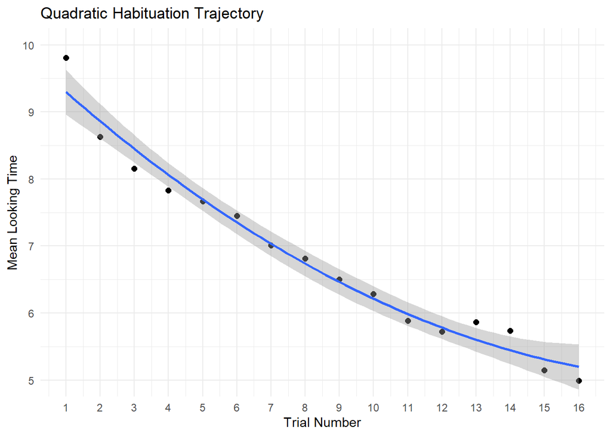

```r
# Quadratic Model
ggplot(data_summary, aes(x = testing_trial, y = mean_lt)) +
  geom_point(size = 2) +
  geom_smooth(method = "lm", formula = y ~ x + I(x^2), se = TRUE, level = 0.95) +
  labs(
    x = "Trial Number",
    y = "Mean Looking Time",
    title = "Quadratic Habituation Trajectory"
  ) +
  coord_cartesian(ylim = c(5, 10)) +
   scale_x_continuous(
    breaks = seq(1, max(data$testing_trial, na.rm = TRUE), by = 1)
  ) +
  theme_minimal()
```

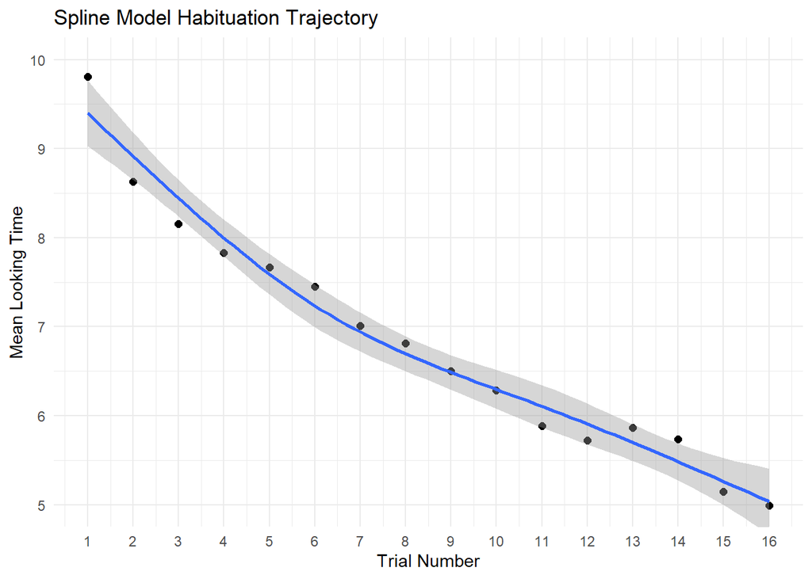

```r
# Spline Model
ggplot(data_summary, aes(x = testing_trial, y = mean_lt)) +
  geom_point(size = 2) +
  geom_smooth(method = "lm", formula = y ~ splines::ns(x, df = 3), se = TRUE, level = 0.95) +
  labs(
    x = "Trial Number",
    y = "Mean Looking Time",
    title = "Spline Model Habituation Trajectory"
  ) +
  coord_cartesian(ylim = c(5, 10)) +
   scale_x_continuous(
    breaks = seq(1, max(data$testing_trial, na.rm = TRUE), by = 1)
  ) +
  theme_minimal()
```

All models in one plot

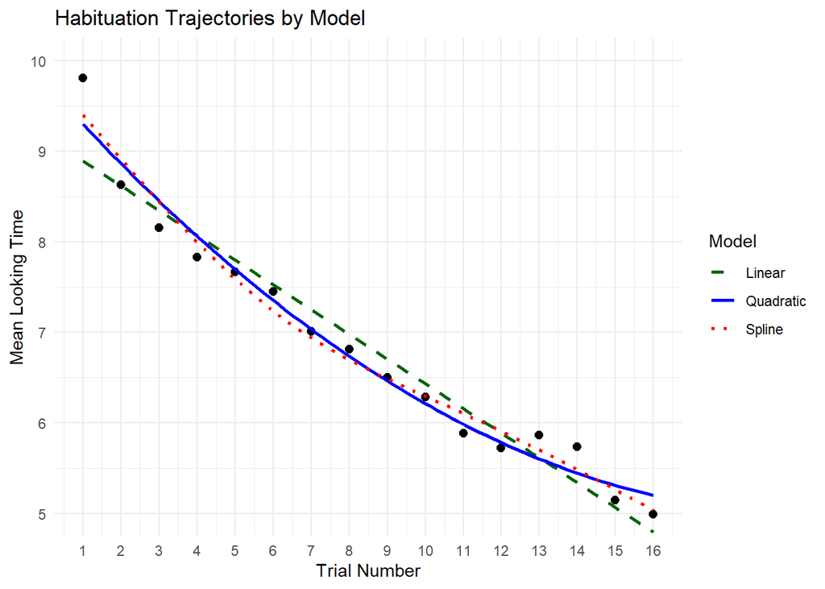

```r
ggplot(data_summary, aes(x = testing_trial, y = mean_lt)) +
  geom_point(size = 2.2, color = "black") +

  geom_smooth(
    aes(color = "Linear", linetype = "Linear"),
    method = "lm",
    formula = y ~ x,
    se = FALSE,
    linewidth = 1
  ) +
  geom_smooth(
    aes(color = "Quadratic", linetype = "Quadratic"),
    method = "lm",
    formula = y ~ x + I(x^2),
    se = FALSE,
    linewidth = 1
  ) +
  geom_smooth(
    aes(color = "Spline", linetype = "Spline"),
    method = "lm",
    formula = y ~ splines::ns(x, df = 3),
    se = FALSE,
    linewidth = 1
  ) +

  scale_color_manual(
    name = "Model",
    values = c(
      "Linear" = "darkgreen",
      "Quadratic" = "blue",
      "Spline" = "red"
    )
  ) +
  scale_linetype_manual(
    name = "Model",
    values = c(
      "Linear" = "dashed",
      "Quadratic" = "solid",
      "Spline" = "dotted"
    )
  ) +
  scale_x_continuous(breaks = 1:16) +
  labs(
    x = "Trial Number",
    y = "Mean Looking Time",
    title = "Habituation Trajectories by Model"
  ) +
  coord_cartesian(ylim = c(5, 10)) +
  theme_minimal()
```

# 2 Individual differences

Identify factors that explain variability across infants.

- 2.1 What factors moderate differences?
- 2.2 Which moderators are most important?
- 2.3 Do moderators relate to different aspects?
- 2.4 Are there identifiable subgroups?

## 2.1 Habituation by Age

I will use the age variable that I previously created by harmonizing the two variables age_group_new and age_days

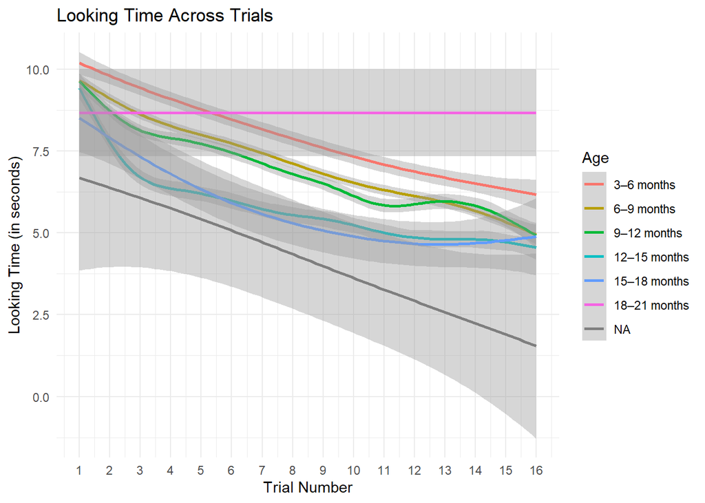

```r
ggplot(data %>% dplyr::filter(testing_trial > 0),
       aes(x = testing_trial, y = looking_time, color = age)) +
  geom_smooth(se = TRUE) +
  scale_color_discrete(
    name = "Age"
  ) +
  labs(
    x = "Trial Number",
    y = "Looking Time (in seconds)",
    title = "Looking Time Across Trials"
  ) +
  scale_x_continuous(
    breaks = seq(1, max(data$testing_trial, na.rm = TRUE), by = 1)
  ) +
  theme_minimal()
```

The plot looks strange: Lets check, how many observations are in each age group in the testing trials!

```r
data %>%
  dplyr::filter(testing_trial > 0) %>%
  dplyr::count(age)
```

```
           age     n
1   < 3 months     6
2   3–6 months  5942
3   6–9 months 18194
4  9–12 months 14039
5 12–15 months 10811
6 15–18 months   575
7 18–21 months    52
8         <NA>    16
```

There are few observations in 15-18 and 18-21 months. I will remove NA category for plotting, and add 15-21 months into a single category to make the sample bigger.

```r
data <- data %>%
  mutate(new_age = recode(age,
                              "< 3 months" = "< 3 months",
                              "3–6 months" = "3–6 months",
                              "6–9 months" = "6–9 months",
                              "9–12 months" = "9–12 months",
                              "12–15 months" = "12–15 months",
                              "15–18 months" = "15–21 months",
                              "18–21 months" = "15–21 months",
                              "21+ months" = "21+ months"))

# check new age-variable
data %>%
  dplyr::filter(testing_trial > 0) %>%
  dplyr::count(new_age)
```

```
       new_age     n
1   < 3 months     6
2   3–6 months  5942
3   6–9 months 18194
4  9–12 months 14039
5 12–15 months 10811
6 15–21 months   627
7         <NA>    16
```

Plot again with new variable and without NA group (16 observations), with 95% confidence intervals

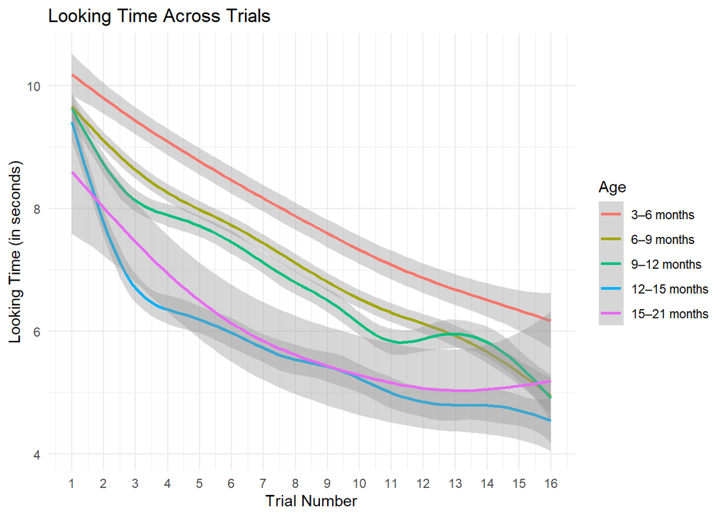

```r
ggplot(data %>% dplyr::filter(testing_trial > 0, !is.na(age) ),
       aes(x = testing_trial, y = looking_time, color = new_age)) +
  geom_smooth(se = TRUE, level = 0.95) +
  scale_color_discrete(
    name = "Age"
  ) +
  labs(
    x = "Trial Number",
    y = "Looking Time (in seconds)",
    title = "Looking Time Across Trials"
  ) +
  scale_x_continuous(
    breaks = seq(1, max(data$testing_trial, na.rm = TRUE), by = 1)
  ) +
  theme_minimal()
```

## 2.2 Habituation by Sex of Participant

There seems to be no sex difference overall! Maybe if we stratify the data by other factors later on.

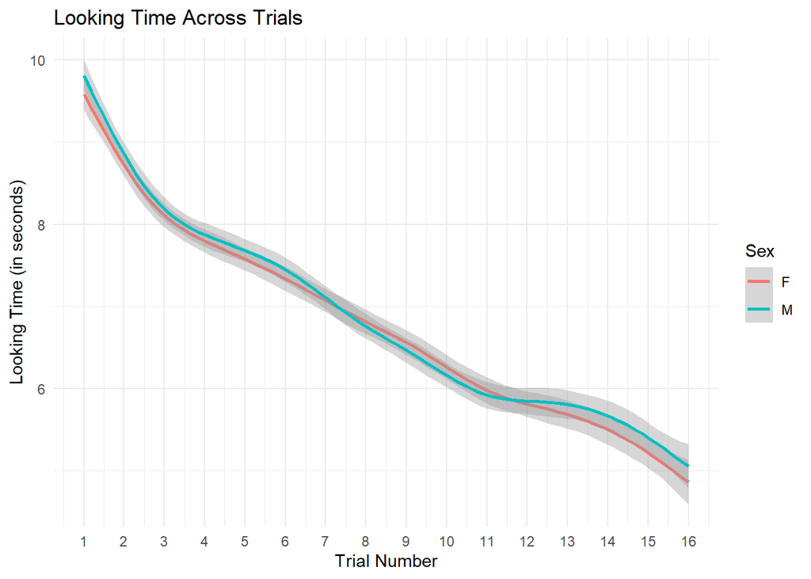

```r
ggplot(data %>% dplyr::filter(testing_trial > 0, !is.na(participant_sex) ),
       aes(x = testing_trial, y = looking_time, color = participant_sex)) +
  geom_smooth(se = TRUE) +
  scale_color_discrete(
    name = "Sex"
  ) +
  labs(
    x = "Trial Number",
    y = "Looking Time (in seconds)",
    title = "Looking Time Across Trials"
  ) +
  scale_x_continuous(
    breaks = seq(1, max(data$testing_trial, na.rm = TRUE), by = 1)
  ) +
  theme_minimal()
```

## 2.3 Habituation by Gender of Primary Caregiver

```r
# check amount of data per category
data %>%
dplyr::filter(testing_trial > 0) %>%
dplyr::count(primarycaregiver_gender)
```

```
  primarycaregiver_gender     n
1                       F 44388
2                       M  4457
3                   other    71
4                   OTHER     4
5                    <NA>   715
```

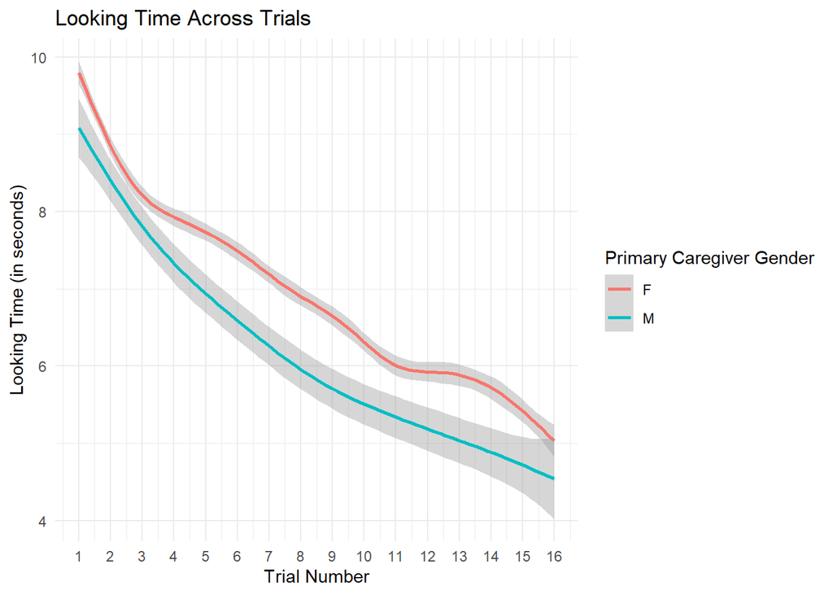

```r
# "other" and "OTHER" are just 75 observations, compared to 44000 F and 4500 M, remove "other" due to severely missing data for plotting

ggplot(data %>% dplyr::filter(
         !is.na(primarycaregiver_gender),
         !primarycaregiver_gender %in% c("other", "OTHER")),
       aes(x = testing_trial, y = looking_time, color = primarycaregiver_gender)) +
  geom_smooth(se = TRUE, level = 0.95) +
  scale_color_discrete(
    name = "Primary Caregiver Gender"
  ) +
  labs(
    x = "Trial Number",
    y = "Looking Time (in seconds)",
    title = "Looking Time Across Trials"
  ) +
  scale_x_continuous(
    breaks = seq(1, max(data$testing_trial, na.rm = TRUE), by = 1)
  ) +
  theme_minimal()
```

## 2.4 Habituation by Language Group

```r
# check amount of data per category
data %>%
dplyr::filter(testing_trial > 0) %>%
dplyr::count(language_group)
```

```
  language_group     n
1      bilingual  6262
2    monolingual 42847
3          other    71
4           <NA>   455
```

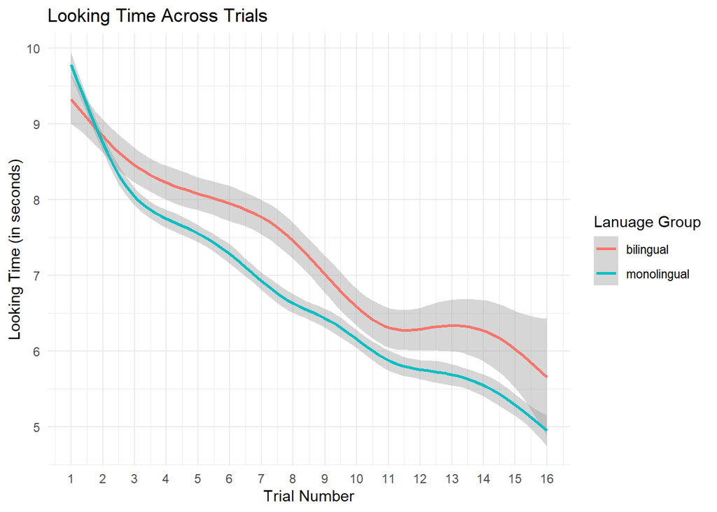

```r
# "other" and "OTHER" are just 71 observations, remove them for plotting

ggplot(data %>% dplyr::filter(!is.na(language_group),
                              !language_group %in% c("other")),
       aes(x = testing_trial, y = looking_time, color = language_group)) +
          geom_smooth(se = TRUE, level = 0.95) +
          scale_color_discrete(
            name = "Lanuage Group"
          ) +
          labs(
            x = "Trial Number",
            y = "Looking Time (in seconds)",
            title = "Looking Time Across Trials"
          ) +
          scale_x_continuous(
            breaks = seq(1, max(data$testing_trial, na.rm = TRUE), by = 1)
          ) +
          theme_minimal()
```

# 3 Methodological effects

Assess how methodological choices influence results.

- 3.1 Do differences contribute to variability?
- 3.2 Do they affect interpretation?
- 3.3 Do they affect reliability?

## 3.1 Habituation by Trial Type

```r
# check amount of data per category
data %>%
dplyr::filter(testing_trial > 0) %>%
dplyr::count(trial_type)
```

```
    trial_type     n
1          ADS 16820
2   consistent  3978
3          fam     1
4          IDS 16805
5 inconsistent  3977
6    nonsocial  3837
7       social  3959
8        TRAIN    70
9         <NA>   188
```

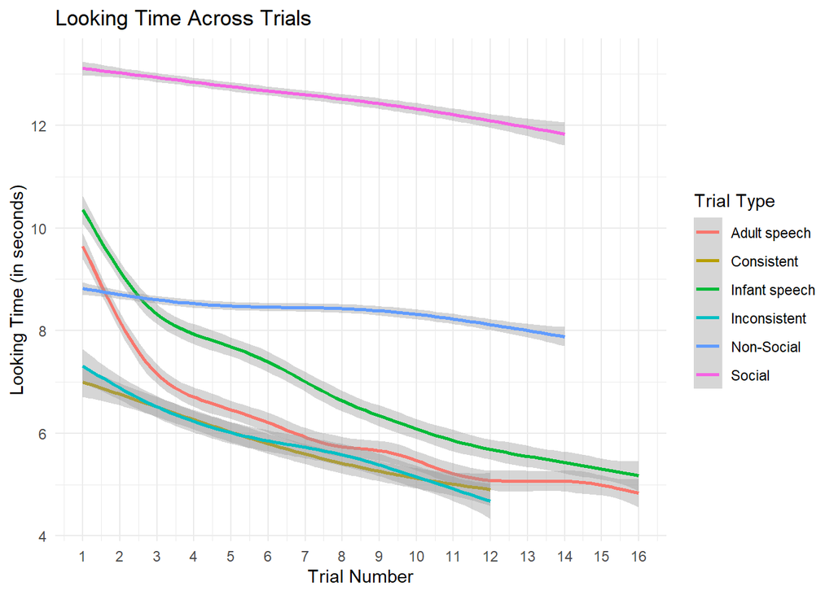

```r
ggplot(data, aes(x = testing_trial, y = looking_time, color = trial_type)) +
  geom_smooth(se = TRUE) +
  scale_color_discrete(
    name = "Trial Type",
    labels = c(
      "ADS" = "Adult speech",
      "IDS" = "Infant speech",
      "consistent" = "Consistent",
      "inconsistent" = "Inconsistent",
      "nonsocial" = "Non-Social",
      "social" = "Social"
    )
  ) +
  labs(
    x = "Trial Number",
    y = "Looking Time (in seconds)",
    title = "Looking Time Across Trials"
  ) +
  scale_x_continuous(
    breaks = seq(1, max(data$testing_trial, na.rm = TRUE), by = 1)
  ) +
  theme_minimal()
```

## 3.2 Habituation by Project ID

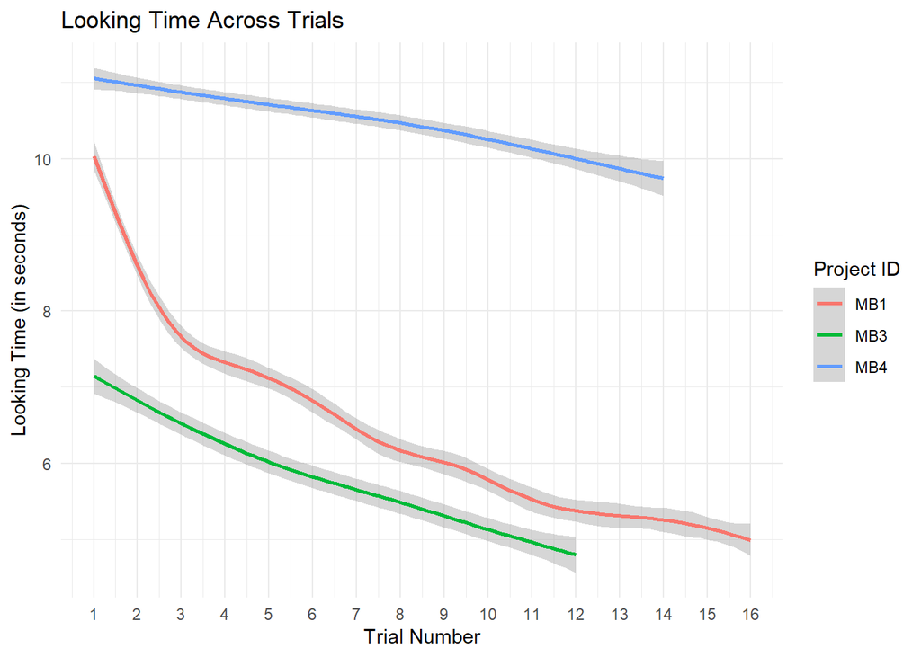

```r
ggplot(data, aes(x = testing_trial, y = looking_time, color = project_id)) +
  geom_smooth(se = TRUE) +
  scale_color_discrete(
    name = "Project ID") +
  labs(
    x = "Trial Number",
    y = "Looking Time (in seconds)",
    title = "Looking Time Across Trials"
  ) +
  scale_x_continuous(
    breaks = seq(1, max(data$testing_trial, na.rm = TRUE), by = 1)
  ) +
  theme_minimal()
```

#### 3.2.0.1 Habituation by Method

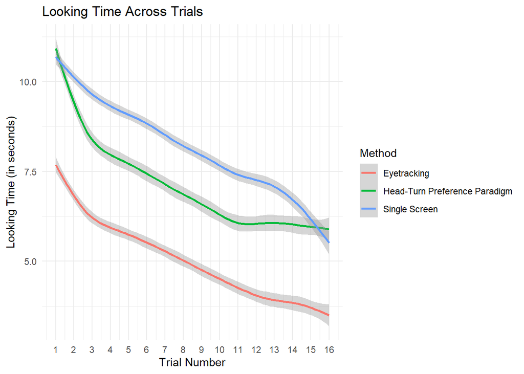

```r
ggplot(data, aes(x = testing_trial, y = looking_time, color = method)) +
  geom_smooth(se = TRUE) +
  scale_color_discrete(
    name = "Method",
    labels = c(
      "eyetracking" = "Eyetracking",
      "hpp" = "Head-Turn Preference Paradigm",
      "singlescreen" = "Single Screen")
  ) +
  labs(
    x = "Trial Number",
    y = "Looking Time (in seconds)",
    title = "Looking Time Across Trials"
  ) +
   scale_x_continuous(
    breaks = seq(1, max(data$testing_trial, na.rm = TRUE), by = 1)
  ) +
  theme_minimal()
```

## 3.3 Habituation by Caregiver Seat

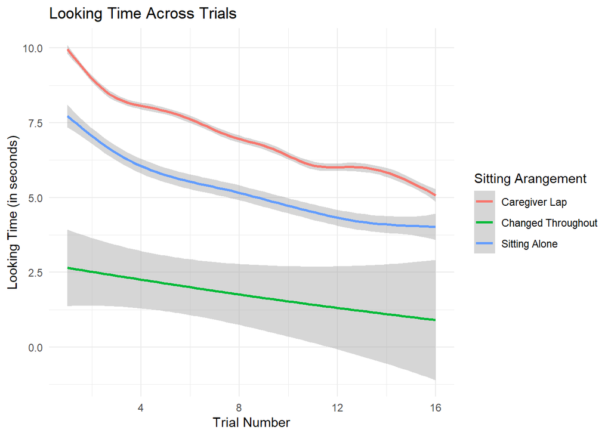

```r
ggplot(data %>% dplyr::filter(!is.na(caregiver_seat)),
       aes(x = testing_trial, y = looking_time, color = caregiver_seat)) +
  geom_smooth(se = TRUE) +
  scale_color_discrete(
    name = "Sitting Arangement",
    labels = c(
      "caregiver_lap_only" = "Caregiver Lap",
      "seat_alone_only" = "Sitting Alone",
      "changed_throughout" = "Changed Throughout")
  ) +
  labs(
    x = "Trial Number",
    y = "Looking Time (in seconds)",
    title = "Looking Time Across Trials"
  ) +
  theme_minimal()
```